# What to blame?

Robazza Alberto

## Car pollution… What to blame?

Everyone can dream about an ideal cars that perfectly match his needs.

## But…

Since the environment needs to be preserved, what should governments and manufacturers limit?

We will split cars in some big groups:  
- **City cars**  
- **Long-distance cars**  
- **Off-road vehicles**  
- **Sport cars**

Let’s do some hypothesis with interesting data…

## Correlation between CO2 by Km and liters by 100 Km

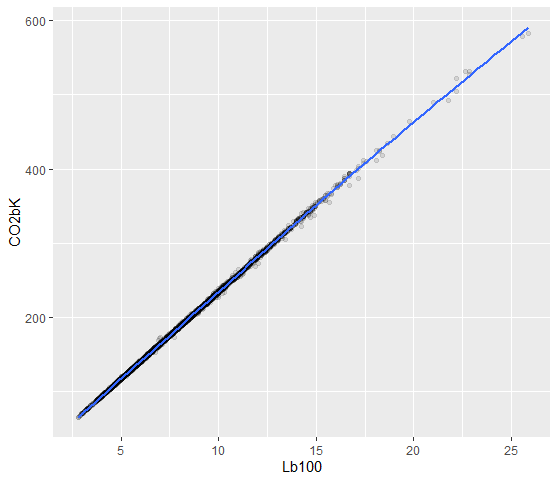

```
## [1] 0.9997781
```

## Cylinders

- Sport cars and long-distance cars: not too little in order to reduce vibration

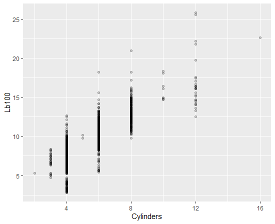

```
## [1] 0.8227127
```

## Horsepower

- Sport cars: needed to reach higher speed and better acceleration

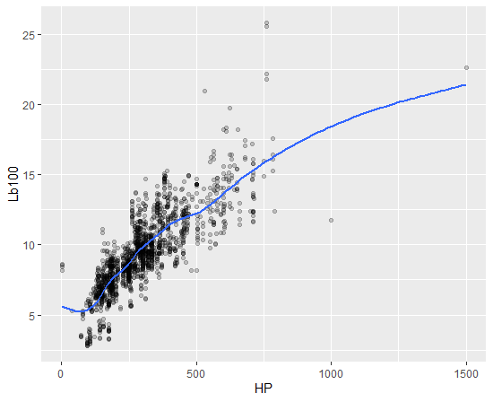

```
## [1] 0.8168141
```

## Weight

- Sports cars: heaviest mass at the bottom
- Off road vehicles: total weight lowest as possible

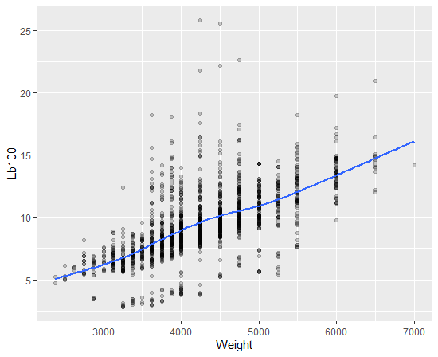

```
## [1] 0.6476253
```

## Gears and air drag coefficient

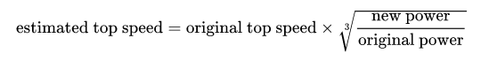

We can also increase the maximum speed by reducing the acceleration adjusting gears ratio.

- Long distance cars: reduced air drag coefficient can increase liters by 100 Km keeping th same maximum speed
- Sport cars: reduced air drag coefficient can increase maximum speed
- City cars: acceleration over maximum speed
- Off-road cars: maximize acceleration (reduced gears)

## Conclusion

Everyone would decrease emissions, we have to keep in mind different type of cars meets different needs and have different aims.

## Bibliography

- [Data source (epa.gov)](https://www.epa.gov/sites/production/files/2020-10/19tstcar-2020-10-02.xlsx)
- [Air drag ocefficient (en.wikipedia.org)](https://en.wikipedia.org/wiki/Drag_coefficient)
- [Speed formula (en.wikipedia.org)](https://en.wikipedia.org/wiki/Automobile_drag_coefficient)
- [Weight versus slope (pianetaciclismo.com)](http://www.pianetaciclismo.com/categoria/training/rapporto_peso_potenza/3.html)

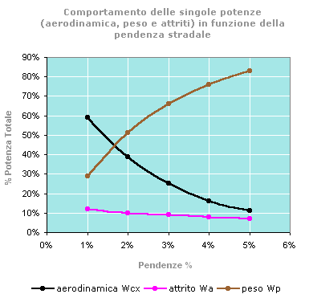

## Notes

- Almost every graph and correlation is made by gasoline cars and FTP emission test cycle